# Gene expression profiling of bovine raw milk as a new tool to monitor the inflammatory status of the udder : a pilot study

Pierre Germon

2026-04-17

## Loading of libraries

```r
library(ggplot2)
library(RColorBrewer)
library(lattice)
library(reshape2)
library(pheatmap)
library(plyr)
library(knitr)
library(gplots)
library(circlize)
library(FactoMineR)
library(factoextra)
library(corrplot)
library(readxl)
library(ggplot2)
library(lubridate)
library(dplyr)
library(tidyr)
library(here)
library(stringr)
library(tidyverse)
library(writexl)
library(readxl)
library(psych)
library(dendextend) # for dendrogram analyses
library(DescTools) # for LRT test
library(ggpubr)
```

## Setting the current working directory

Update the code below to set the current working directory to the directory that contains all the required files (raw data, metadata,…)

```r
# main working directory
wd <- c("/Users/pgermon/Documents/Divers_labo/Publis/2024_Gitton/Soumission_PLOS_ONE/R_markdown_doc")

#get date
date <- as.character(Sys.Date())
figure_directory <- paste0(wd,"/Figures_",date)
table_directory <- paste0(wd,"/New_tables_", date)

#directory original data
wd_sorted_cells_data <- paste0(wd,"/Raw_data_and_metadata/Sorted_cells")
wd_milk_samples_data <- paste0(wd,"/Raw_data_and_metadata/Milk_samples")

# create a repertoire to store files resulting from the analyses
dir.create(figure_directory)

#create a repertoire to store tables
dir.create(table_directory)
```

## Part one: selection of cell-type specific genes

### Loading the data

We need to load the raw data file exported from the Fluidigm Data Analysis software. The data was exported as csv file and converted to .xlsx file.

```r
#set the working directory to the Sorted_cells folder
setwd(wd_sorted_cells_data)

#raw BiomarkHD results
export <- read_xlsx("Raw_data_ct_sorted_cells.xlsx")

#files containg the Tm values for each analyzed gene
table_Tm<-read_xlsx("Table_tm_sorted_cells.xlsx")

#description of samples####
description <- read_xlsx("Description_sorted_cells.xlsx")

#metadata table containing cell count results, cow data and bacteriology analyses####
comptages <- read_xlsx(paste0(wd_milk_samples_data,"/Supplementary_table_S1_milk_samples.xlsx"))
```

### Cleaning raw data file

The different steps are to add the description of the samples to the raw data file. Then the theoretical Tm value is added to the table for further calculations. Genes for which a Tm could not be determined are removed. Samples with Tm outside of a +/- 0.7° window from the theoretical Tm are removed. The number of retained genes is indicated.

```r
#merge table ct and sample description
  export1 <-  export %>%
    left_join(description, by=c('Name'))

#add Tm column for genes studied####
export2  <-  export1 %>%
  left_join(table_Tm, by=c('Gene'))

#remove samples with no Tm####
export3 <- export2 %>%
  filter(export2$Tm!="ND")
export3$Tm <- as.numeric(export3$Tm)

# first filter : determine samples Tm within the range of +/- 0.7° of correct Tm####
export4 <- export3 %>%
  mutate(tm_max = Tm + 0.7) %>%
  filter(!tm_in > tm_max) %>%
  mutate(tm_min = Tm - 0.7) %>%
  filter(!tm_in < tm_min)

# print the number of genes in the table
print(length(levels(factor(export4$Gene))))
```

```
## [1] 46
```

### Selection of Samples with sufficient data

In order to run a suitable analysis, only samples with less than 10% missing data are retained.

```r
nb_echantillons <- length(levels(factor(export4$Name)))

#select genes with less than 10% missing values####
list_gene_ct999 <- export4 %>%
  count(Gene, ct==999) %>%
  rename("ct999"=c(2)) %>%
  filter(!n< nb_echantillons*0.9) %>%
  mutate(ct999=as.factor(ct999)) %>%
  filter(!ct999==TRUE)

export5 <- export4 %>%
  semi_join(list_gene_ct999, by=c('Gene'))
```

A new table is created arranged by sample and genes and missing Ct values are adjusted: for each gene, missing value is given the Ct value higher of the (highest Ct for this gene +1 ).

```r
#simplified table containing only sample names, gene names and Ct values####
table_simplifiee <- export5[,c("Name","Gene", "ct")]

#list of all genes retained for analysis
liste_genes <- levels(factor(table_simplifiee$Gene))

table_ct <- table_simplifiee %>%
  pivot_wider(names_from = Gene, values_from = ct)

#adjust missing Ct values for a gene to max(Ct) +1 ####
for (i in (2:ncol(table_ct))) {
  # i <- 23
  max <- max(table_ct[i][!is.na(table_ct[i])])
  table_ct[i][is.na(table_ct[i])] <- max +1
}
```

### Calculation of fold-changes

Then a control sample is calculated and used for calculation of FC and log2FC according to ‘https://toptipbio.com/qpcr-multiple-reference-genes/’

```r
# reference sample
  moyenne <- sapply(table_ct[,2:ncol(table_ct)],mean, na.rm=T)
  control<-c("CTRL",moyenne)


  #a matrix with all ct values is created
  matrice <- data.frame(table_ct[,2:ncol(table_ct)])

  #and each value is converted to numerics
  matrice[,1:ncol(matrice)] <- apply(matrice[,1:ncol(matrice)], 2, function(x)  as.numeric(as.character(x)))

  #∆Ct calculation
  matrice_delta_ct <- -sweep(matrice,2,moyenne)

  #matrix of RQ
  matrice_RQ <- sapply(matrice_delta_ct, function(x) 2^x)
  row.names(matrice_RQ) <- table_ct$Name


  #Calculate the geometric mean of the reference genes RQ values
  genes_REF<-c("ACTB","GAPDH")
  matrice_RQ_ref <- matrice_RQ[,genes_REF]

  RQ_geom_mean <- geometric.mean(t(matrice_RQ_ref), na.rm=T)

  matrice_RQ_geom <- matrice_RQ / RQ_geom_mean

  table_fc <- data.frame("Name"=rownames(matrice_RQ_geom), matrice_RQ_geom)

  table_log_fc <- data.frame("Name" = rownames(matrice_RQ_geom), log2(matrice_RQ_geom))

  head(table_log_fc[,1:5])
```

```
##              Name        ACTB         AHR         Bax     CASP13
## ADNc-362 ADNc-362 -0.05706834 -0.26229541 -0.52790830  2.0678549
## ADNc-363 ADNc-363 -0.34965920 -0.40527297  0.29633320 -1.4429508
## ADNc-364 ADNc-364  0.49791979  0.97327739 -0.20905770 -2.0853095
## ADNc-365 ADNc-365  0.24265805 -0.15242010  0.09570899  2.2149106
## ADNc-366 ADNc-366 -0.26998006 -0.07586602  0.34114657 -0.7320131
## ADNc-367 ADNc-367  0.62867043  0.37060836  0.80427058 -1.6559258
```

The description of samples is added to the `table_fc` and `table_log_fc`. The log2FC table is written to an excel file.

```r
#add description to table_log_fc####
table_log_fc <- merge(table_log_fc, description, by="Name")

#add cell counts####
table_log_fc <- merge(table_log_fc, comptages, by="Quarter")


#definition table####

table_sorted_cells <- table_log_fc


write_xlsx(table_sorted_cells, paste0(table_directory,"/table_log2FC_sorted_cells.xlsx"))
```

### Identification of genes differentially expressed between the three cell types

Genes expressed differently between cell types are identified using a Kruskall-Wallis test.

```r
#a new variable is created with the cell type of each sample
type <- table_sorted_cells$Type

# a function is created to calculate p-value (Kruskall-Wallis test)
p_values_KW <- function(gene){
  kruskal.test(gene ~ type)$p.value
}

table_p_KW <- sapply(table_sorted_cells[, is.element(colnames(table_sorted_cells),liste_genes)], FUN = p_values_KW)
table_p_KW <- data.frame(Name = names(table_p_KW), p_value = table_p_KW)

#list of genes differentially expressed
table_dif_KW <- table_p_KW[table_p_KW$p_value < 0.05,]
gene_dif_KW <- table_p_KW$Name[table_p_KW$p_value < 0.05]

#the list is written to an excel file
write_xlsx(table_dif_KW, paste0(table_directory,"/liste_genes_diff_KW.xlsx"))

# number of genes differentially expressed between cell types
paste0("The number of genes selected in the table_log_fc table is ",length(gene_dif_KW))
```

```
## [1] "The number of genes selected in the table_log_fc table is 37"
```

### Figure 1A: Representation as a heatmap of the log2FC of the differentially expressed genes

The log2FC values for the genes identified as differentially expressed are retrived in a new matrix `matric_heatmap`.

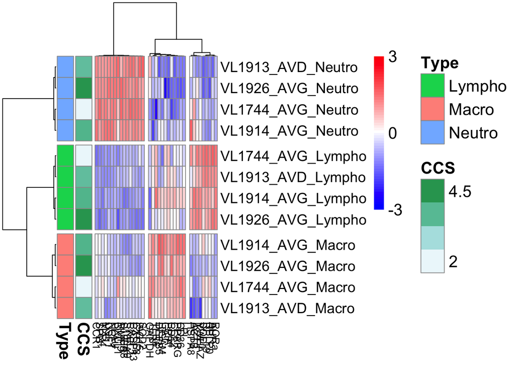

```r
#heatmap of log2FC for genes identified as differentially expressed
matrix_heatmap <- table_sorted_cells[,is.element(colnames(table_sorted_cells),gene_dif_KW)]

rownames(matrix_heatmap) <- paste0(table_sorted_cells$Quarter,"_",table_sorted_cells$Type)

myBreaks <- c(seq(-3, 3,by=0.1))
paletteLength<-length(myBreaks)
myColor <- colorRampPalette(c("blue","white","red"))(paletteLength)

annotation_row <- data.frame(
  CCS=log2(table_sorted_cells$CCS /100)+3,
  Type = factor(table_sorted_cells$Type)
)

rownames(annotation_row) <- paste0(table_sorted_cells$Quarter,"_",table_sorted_cells$Type)

labs.row <- rownames(matrix_heatmap)

matrix_heatmap <- scale(matrix_heatmap)

p_sorted_cells <- pheatmap(matrix_heatmap,
              # cluster_rows = F,
              cutree_cols = 3,
              cutree_rows = 3,
              clustering_method = "ward.D",
              clustering_distance_cols = "correlation",
              clustering_distance_rows = "correlation",
              # annotation_colors = ann_colors,
              annotation_row = annotation_row,
              breaks = myBreaks,
              legend_breaks = c(-3,0,3),

              fontsize_row = 14,
              fontsize_col = 10,
              fontsize = 16,

              color = myColor,
              labels_row = labs.row,
              # main=titre
)
```

The three genes clusters identified by the hierachical clustering are retrieved in a data.frame and saved as an excel file.

```r
#create table with list of selected genes####
cluster_genes <- data.frame(Gene = names(cutree(p_sorted_cells$tree_col, k=3)),
                          Type_gene = cutree(p_sorted_cells$tree_col, k=3))
cluster_genes$Type_gene <- gsub("1", "Lympho", cluster_genes$Type_gene)
cluster_genes$Type_gene <- gsub("2", "Neutro", cluster_genes$Type_gene)
cluster_genes$Type_gene <- gsub("3", "Macro", cluster_genes$Type_gene)
write_xlsx(cluster_genes, paste0(table_directory,"/Supplementary_table_S3_gene_clusters.xlsx"))
```

The heatmap is then updated to show the gene clusters.

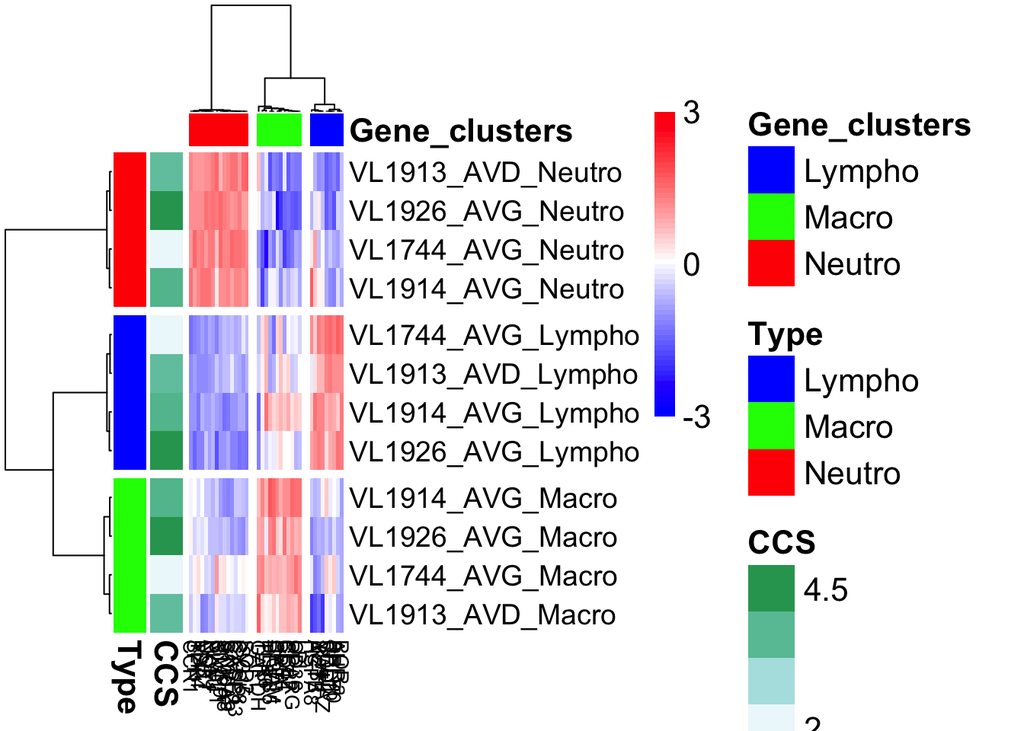

```r
matrix_heatmap <- table_sorted_cells[,is.element(colnames(table_sorted_cells),gene_dif_KW)]

table_genes <- read_xlsx(paste0(table_directory,"/Supplementary_table_S3_gene_clusters.xlsx"))

rownames(matrix_heatmap) <- paste0(table_sorted_cells$Quarter,"_",table_sorted_cells$Type)

myBreaks <- c(seq(-3, 3,by=0.1))
paletteLength<-length(myBreaks)
myColor <- colorRampPalette(c("blue","white","red"))(paletteLength)

ann_colors = list(
  Gene_clusters = c("Lympho"="blue",
            "Macro"="green",
            "Neutro"="red"

           ),
  Type = c("Lympho"="blue",
            "Macro"="green",
            "Neutro"="red")
)


annotation_row <- data.frame(
  CCS = log2(table_sorted_cells$CCS /100)+3,
  Type = factor(table_sorted_cells$Type)
)

rownames(annotation_row) <- paste0(table_sorted_cells$Quarter,"_",table_sorted_cells$Type)

annotation_col <- data.frame(
  Gene_clusters = factor(table_genes$Type_gene)
)
rownames(annotation_col) <- table_genes$Gene

labs.row <- rownames(matrix_heatmap)

matrix_heatmap <- scale(matrix_heatmap)

p_sorted_cells <- pheatmap(matrix_heatmap,
              # cluster_rows = F,
              cutree_cols = 3,
              cutree_rows = 3,
              clustering_method = "ward.D",
              clustering_distance_cols = "correlation",
              clustering_distance_rows = "correlation",
              annotation_colors = ann_colors,
              annotation_row = annotation_row,
              annotation_col = annotation_col,
              breaks = myBreaks,
              legend_breaks = c(-3,0,3),

              fontsize_row = 14,
              fontsize_col = 10,
              fontsize = 16,

              color = myColor,
              labels_row = labs.row,
              # main=titre
)
```

The new heatmpap is saved to a tiff file.

```r
tiff(paste0(figure_directory,"/Figure_1A_heatmap_sorted_cells.tif"), width = 12, height = 8.5, units = "in", res = 150)
p_sorted_cells
dev.off()
```

### Figure 1B: Representation as a PCA of the log2FC of the differentially expressed genes

The log2FC values for the genes identified as differentially expressed were then alayzed by Principal Component Analysis.

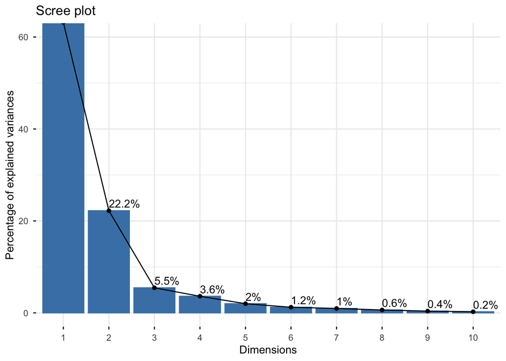

```r
matrix_pca <- table_sorted_cells[,is.element(colnames(table_sorted_cells),gene_dif_KW)]

rownames(matrix_pca) <- paste0(table_sorted_cells$Quarter,"_",table_sorted_cells$Type)


library(FactoMineR)

res.pca <- PCA(matrix_pca,
               graph = F)

eig.val <- get_eigenvalue(res.pca)
fviz_eig(res.pca, addlabels = TRUE, ylim = c(0, 60))
```

```r
ind <- get_pca_ind(res.pca)


color <- as.factor(table_sorted_cells$Type)


pca_ind_plot <- fviz_pca_ind(res.pca,
             axes = c(1,2),
             # pointshape = as.factor(table_analyse$Cluster_4_samples),
             pointsize = 5,
             # col.ind = "cos2",
             col.ind=color,
             # fill.ind=color,
             # gradient.cols = c("green","blue","orange","yellow"),
             palette = c("blue","green","red"),
             # palette = c("blue","cyan","orange","red"),
             repel = TRUE, # Avoid text overlapping (slow if many points)
             addEllipses = T,
             ellipse.type = "confidence",
             ellipse.level=0.99,
             mean.point = FALSE,
             label = "none",
             title = " ",
             legend.title = "Cell types"
             ) +
  theme_bw() +
  theme(axis.text.x = element_text(angle = 0, size=20),
        axis.text.y = element_text(size = 20),
        axis.title.x = element_text(size = 25),
        axis.title.y = element_text(size = 25),
        axis.title.x.top = element_text(size = 25),
        strip.text = element_text(size = 15),
        legend.title = element_text(size = 20),
        legend.text = element_text(size = 15)
  )

tiff(paste0(figure_directory,"/Figure_1B_PCA_cell_triee.tif"), width = 8.5, height = 8.5, units = "in", res = 150)
pca_ind_plot
```

```
## Ignoring unknown labels:
## • linetype : "Cell types"
```

```r
dev.off()
```

## Part two: analysis of milk RNA samples

### Loading of raw data

Data are loaded.

```r
#set working directory for milk samples
setwd(wd_milk_samples_data)

#Tm table####
table_Tm<-read_xlsx("Table_tm_milk_samples.xlsx")

#description of samples####
description <- read_xlsx("Description_milk_samples.xlsx")

#cell counts table####
comptages <- read_xlsx("Supplementary_table_S1_milk_samples.xlsx")

#raw BiomarkHD results####
export <- read_xlsx("Raw_data_ct_milk_samples.xlsx")
```

and then cleaned to only keep relevant samples (the original BiomarkHD also includes samples not related to this study). The TXNRD1 primers were not correct so data for this gene are removed.

```r
#remove non relevant samples####
export1 <- export %>%
  filter(!str_detect(Name,"ANSES"))

#remove TXNRD1 samples####
export1 <- export1 %>%
  filter(!str_detect(Gene,"TXNRD1"))

#add Tm column for genes studied####
export2  <-  export1 %>%
  left_join(table_Tm, by=c('Gene'))

#add description column####
export3  <-  export2 %>%
  left_join(description, by=c('Name'))

#remove samples with no Tm####
export4 <- export3 %>%
  filter(export3$tm_std!="ND")
export4$tm_std <- as.numeric(export4$tm_std)

# first filter : determine samples Tm within the range of +/- 0.7° of correct Tm####
export6 <- export4 %>%
  mutate(tm_max=tm_std + 0.7) %>%
  filter(!tm_in > tm_max) %>%
  mutate(tm_min=tm_std - 0.7) %>%
  filter(!tm_in<tm_min)
```

Only samples from milk RNA are selected. Samples with less than 20% missing values are selected and missing values are corrected. Sample ADNc-349 as it gave aberant values.

```r
#selection of milk samples only
analyse <- c("Milk samples")
quarter_to_keep <- description$Quarter[description$Type=="lait" & !is.na(description$Type)]
samples_to_keep <- description$Name[is.element(description$Quarter,quarter_to_keep) &
                                             (description$Type=="lait") &
                                             description$Extraction!="qiagen" &
                                             description$Name != "ADNc-349"]

#restrict table to samples to keep####
export7 <- export6[is.element(export6$Name,samples_to_keep),]

nb_echantillons <- length(levels(factor(export7$Name)))

#select genes with less than 20% missing values####
list_gene_ct999_bis <- export7 %>%
  count(Gene, ct==999) %>%
  rename("ct999"=c(2))

list_gene_ct999 <- export7 %>%
  count(Gene, ct==999) %>%
  rename("ct999"=c(2))%>%
  filter(!n < nb_echantillons*0.8) %>%
  mutate(ct999=as.factor(ct999)) %>%
  filter(!ct999==TRUE)

export8 <- export7 %>%
  semi_join(list_gene_ct999, by=c('Gene'))


#simplified table containing only sample names, gene names and Ct values####
table_simplifiee <- export8[,c("Name","Gene", "ct")]


table_ct <- table_simplifiee %>%
  pivot_wider(names_from = Gene, values_from = ct)

#adjust missing Ct values for a gene to max(Ct) +1 ####
for (i in (2:ncol(table_ct))) {
  # i <- 23
  max <- max(table_ct[i][!is.na(table_ct[i])])
  table_ct[i][is.na(table_ct[i])] <- max +1
}
```

### Calculation of FC

FC are calculated from a control sample built from an average of the Ct for each gene.

```r
# reference for DDct https://toptipbio.com/qpcr-multiple-reference-genes/####
moyenne <- sapply(table_ct[,2:ncol(table_ct)],mean, na.rm=T)
control<-c("CTRL",moyenne)


#creer matrice avec toutes les valeurs
matrice <- data.frame(table_ct[,2:ncol(table_ct)])
#convertir tous en nombre
matrice[,1:ncol(matrice)] <- apply(matrice[,1:ncol(matrice)], 2, function(x) as.numeric(as.character(x)))

#matrice des ∆Ct : retirer la valeur du groupe contrôle, ici geometrique_moyenne
matrice_delta_ct <- -sweep(matrice,2,moyenne)

#matrice des RQ
matrice_RQ <- sapply(matrice_delta_ct, function(x) 2^x)
row.names(matrice_RQ) <- table_ct$Name


#Calculate the geometric mean of the reference genes RQ values
genes_REF<-c("ACTB","GAPDH")
matrice_RQ_ref <- matrice_RQ[,genes_REF]

RQ_geom_mean <- geometric.mean(t(matrice_RQ_ref), na.rm=T)

matrice_RQ_geom <- matrice_RQ / RQ_geom_mean

table_fc <- data.frame("Name"=rownames(matrice_RQ_geom), matrice_RQ_geom)

table_log_fc <- data.frame("Name"=rownames(matrice_RQ_geom), log2(matrice_RQ_geom))
```

Metadata (description of sample and SCC values) are added to the table of log2FC and the table is stored as an excel file.

```r
table_log_fc <- merge(table_log_fc, description, by="Name")
table_log_fc <- merge(table_log_fc, comptages, by="Quarter")
```

### Figure 2A: Representation of results as heatmap

A matrix data is created with only the data for the genes listed in `gene_dif_KW` and selected above as differentially expressed between cell types.

```r
#restriction to specified set
matrix_heatmap <- table_log_fc[,is.element(colnames(table_log_fc),gene_dif_KW)]
rownames(matrix_heatmap) <- table_log_fc$Quarter
```

The number of genes with sufficient signal and belonging to the list of differentially expressed genes is recorded.

```r
#number of genes in table_log_fc table
paste0("The number of genes selected in the table_log_fc table is ",ncol(matrix_heatmap))
```

```
## [1] "The number of genes selected in the table_log_fc table is 34"
```

Color instructions are selected.

```r
myBreaks <- c(seq(-3, 3,by=0.1))
paletteLength<-length(myBreaks)
myColor <- colorRampPalette(c("blue","white","red"))(paletteLength)

ann_colors = list(
  Gene_clusters = c(
    "Lympho"="blue",
    "Macro"="green",
    "Neutro"="red")
)

annotation_col <- data.frame(
  Gene_clusters = factor(cluster_genes$Type_gene)
)
rownames(annotation_col) <- cluster_genes$Gene

labs.row<-rownames(matrix_heatmap)
```

The heatmap is drawn.

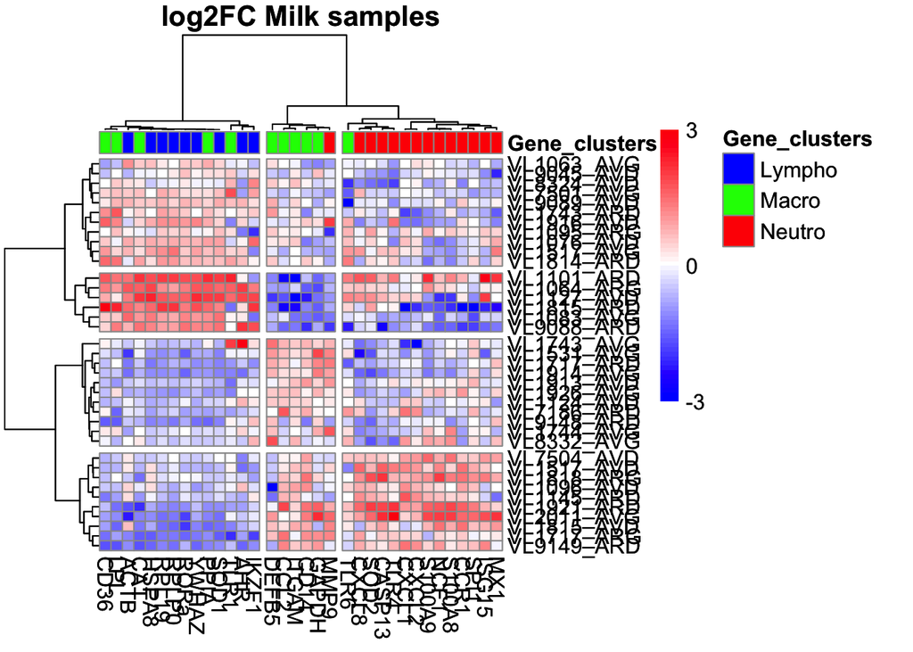

```r
titre<-paste0("log2FC ",analyse)


matrix_heatmap <- scale(matrix_heatmap)

p_milk_cells <- pheatmap(matrix_heatmap,
              # cluster_rows = F,
              cutree_cols = 3,
              cutree_rows = 4,
              clustering_method="ward.D",
              clustering_distance_cols ="correlation",
              # clustering_distance_rows ="correlation",
              annotation_colors = ann_colors,
              annotation_col = annotation_col,
              breaks=myBreaks,
              legend_breaks=c(-3,0,3),

              fontsize = 12,
              color=myColor,
              # labels_row = labs.row,
              main=titre

)

p_milk_cells
```

Samples clusters are collected from the heatmap above and an excel file is created with the list of samples and the cluster number to which they belong.

```r
clusters_samples <- data.frame(Quarter = names(cutree(p_milk_cells$tree_row, k=4)),
                               Cluster_sample = cutree(p_milk_cells$tree_row, k=4))

clusters_samples$Cluster_sample_new <- clusters_samples$Cluster_sample
clusters_samples$Cluster_sample_new[clusters_samples$Cluster_sample == 1] <- 2
clusters_samples$Cluster_sample_new[clusters_samples$Cluster_sample == 2] <- 1
clusters_samples$Cluster_sample_new[clusters_samples$Cluster_sample == 3] <- 4
clusters_samples$Cluster_sample_new[clusters_samples$Cluster_sample == 4] <- 3
clusters_samples$Cluster_sample <- clusters_samples$Cluster_sample_new
clusters_samples <- clusters_samples[,1:2]

write_xlsx(clusters_samples, paste0(table_directory,"/Clusters_milk_samples.xlsx"))
```

Heatmap representation of milk samples with the color code based on the clustering.

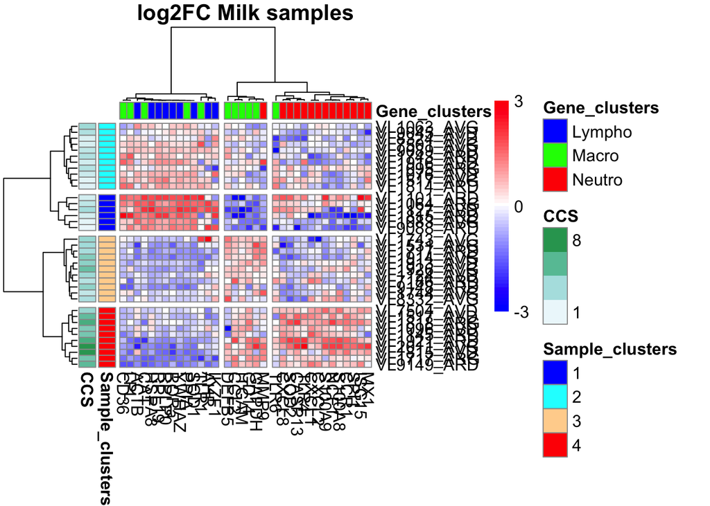

```r
ann_colors = list(
    Gene_clusters = c(
      "Lympho"="blue",
      "Macro"="green",
      "Neutro"="red"),
    Sample_clusters = c("1" = "blue",
                        "2" = "cyan",
                        "3" = "burlywood1",
                        "4" = "red"
                        # "5" = "yellow",
                        # "6" = "black",
                        # "7" = "purple"
    )
  )

annotation_row <- data.frame(
  Sample_clusters = factor(clusters_samples$Cluster_sample),
  CCS = log2(table_log_fc$CCS /100) + 3
  )

rownames(annotation_row) <- clusters_samples$Quarter

annotation_col <- data.frame(
  Gene_clusters = factor(cluster_genes$Type_gene)
)

rownames(annotation_col) <- cluster_genes$Gene

labs.row<-rownames(matrix_heatmap)

p_milk_samples <- pheatmap(matrix_heatmap,
                           cutree_cols = 3,
                           cutree_rows = 4,
                           clustering_method="ward.D",
                           clustering_distance_cols ="correlation",
                           # clustering_distance_rows ="correlation",
                           annotation_colors = ann_colors,
                           annotation_row = annotation_row,
                           annotation_col = annotation_col,
                           breaks=myBreaks,
                           legend_breaks=c(-3,0,3),
                           fontsize = 12,
                           color = myColor,
                           main = titre
                           )
```

The heatmap generated is saved to a tiff file.

```r
tiff(paste0(figure_directory,"/Figure_2A_heatmap_milk_samples.tif"), width = 12, height = 8.5, units = "in", res = 150)
p_milk_samples
dev.off()
```

A table containing the different metadata along with the new clustering is created and stored as an excel file.

```r
table_log_fc <- merge(table_log_fc, clusters_samples, by = "Quarter")

write_xlsx(table_log_fc, paste0(table_directory, "/table_log2FC_milk_samples.xlsx"))
```

### Figure 2C: Statistical analysis of results

A Kruskal-Wallis test is performed on each gene to detect if expression depends on the cluster.

```r
#a new variable is created with the cell type of each sample
cluster <- table_log_fc$Cluster_sample

# a function is created to calculate p-value (Kruskall-Wallis test)
p_values_KW_cluster <- function(gene){
  kruskal.test(gene ~ cluster)$p.value
}


# the Kruskal-Wallis p_value is calculated for each gene
table_p_KW_clusters <- sapply(table_log_fc[, is.element(colnames(table_log_fc),gene_dif_KW)], FUN = p_values_KW_cluster)
table_p_KW_clusters <- data.frame(Name = names(table_p_KW_clusters), p_value = table_p_KW_clusters)


#a function is created to calculate Mann-Whitney test p-values 2 clusters comparisons
p_values_MW_cluster <- function(gene){
  # gene_1_2 <- gene[cluster == 1 | cluster == 2]
  # cluster_1_2 <- cluster[cluster == 1 | cluster == 2]
  p_value_1_2 <- wilcox.test(gene[cluster == 1 | cluster == 2] ~ cluster[cluster == 1 | cluster == 2], exact = T)$p.value
  p_value_1_3 <- wilcox.test(gene[cluster == 1 | cluster == 3] ~ cluster[cluster == 1 | cluster == 3], exact = T)$p.value
  p_value_1_4 <- wilcox.test(gene[cluster == 1 | cluster == 4] ~ cluster[cluster == 1 | cluster == 4], exact = T)$p.value
  p_value_2_3 <- wilcox.test(gene[cluster == 2 | cluster == 3] ~ cluster[cluster == 2 | cluster == 3], exact = T)$p.value
  p_value_2_4 <- wilcox.test(gene[cluster == 2 | cluster == 4] ~ cluster[cluster == 2 | cluster == 4], exact = T)$p.value
  p_value_3_4 <- wilcox.test(gene[cluster == 3 | cluster == 4] ~ cluster[cluster == 3 | cluster == 4], exact = T)$p.value



  return(c(p_value_1_2, p_value_1_3,p_value_1_4, p_value_2_3,  p_value_2_4, p_value_3_4))
}

#the Mann-Whitney p-value for each gene and each comparison is calculated
table_p_1_2_clusters <- sapply(table_log_fc[, is.element(colnames(table_log_fc),gene_dif_KW)], FUN = p_values_MW_cluster)

# only comparisons allowed by the Kruskal-Wallis tests are kept
table_p_1_2_clusters[table_p_KW_clusters > 0.05] <- NA

ordre_genes <- p_milk_samples$tree_col$labels[p_milk_samples$tree_col$order]

table_p_1_2_clusters <- table_p_1_2_clusters[,ordre_genes]

table_p_1_2_clusters[table_p_1_2_clusters > 0.05] <- NA

# for graphic purposes, the opposite of the log(p_value) is calculated and will be represented
table_p_1_2_clusters <- -log(table_p_1_2_clusters)

rownames(table_p_1_2_clusters) <- c("1_vs_2", "1_vs_3", "1_vs_4", "2_vs_3", "2_vs_4", "3_vs_4")

table_p_1_2_clusters <- cbind(c("1_vs_2", "1_vs_3", "1_vs_4", "2_vs_3", "2_vs_4", "3_vs_4"),data.frame(table_p_1_2_clusters))
table_p_1_2_clusters_pivot <- pivot_longer(table_p_1_2_clusters, cols = 2:35)
colnames(table_p_1_2_clusters_pivot) <- c("comparison", "gene", "p_value")

g <- guide_legend("-log10(p-value)")

balloon_plot <- ggplot(table_p_1_2_clusters_pivot, aes(x = factor(gene, levels = ordre_genes), y =  factor(comparison, levels = c("3_vs_4", "2_vs_4", "2_vs_3", "1_vs_4","1_vs_3", "1_vs_2")), fill = p_value, size = p_value)) +
  scale_fill_continuous(palette = c("blue","blue","red"), guide = "legend") +
  guides(fill = g, size = g) +
  geom_point(shape = 21) +
  theme_bw() +
  theme(axis.text.x = element_text(color = "black", size = 15, angle = 90, hjust = .5, vjust = .5, face = "plain"),
        axis.text.y = element_text(color = "black", size = 15, angle = 0, hjust = 1, vjust = 0, face = "plain"),
        axis.title.x = element_text(color = "black", size = 0, angle = 0, hjust = .5, vjust = 0, face = "plain"),
        axis.title.y = element_text(color = "black", size = 0, angle = 90, hjust = .5, vjust = .5, face = "plain")) +
  annotate("rect", xmin = -Inf, xmax = 14.5, ymin = -1, ymax = 12, fill = "blue",
             alpha = 0.2, color= "blue") +
  annotate("rect", xmin = 14.5, xmax = 20.5, ymin = -1, ymax = 12, fill = "green",
             alpha = 0.2, color= "green") +
  annotate("rect", xmin = 20.5, xmax = Inf, ymin = -1, ymax = 12, fill = "red",
             alpha = 0.2, color= "red")


# the figure is generated
tiff(paste0(figure_directory,"/Figure_2C_statistics_milk_samples.tif"), width = 12, height = 4, units = "in", res = 150)
balloon_plot
dev.off()
```

### Figure 2B: PCA representation of results

The results are then represented in the form of a PCA analysis.

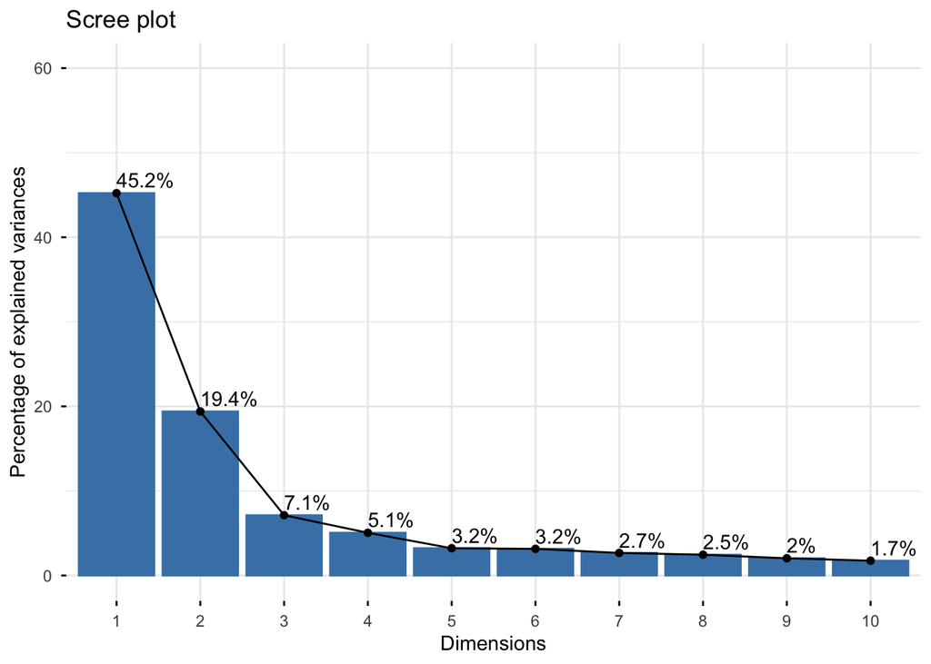

```r
res.pca.milk.samples<- PCA(matrix_heatmap,
                        graph = F)

eig.val.gene.agg <- get_eigenvalue(res.pca.milk.samples)

fviz_eig(res.pca.milk.samples, addlabels = TRUE, ylim = c(0, 60))
```

```r
ind <- get_pca_ind(res.pca.milk.samples)

# color <- table_analyse$SCS
# color <- table_analyse$Macrophage
color <- as.factor(clusters_samples$Cluster_sample)
# color <- as.factor(table_analyse$Type)

pca_ind_plot <- fviz_pca_ind(res.pca.milk.samples,
                             axes = c(1,2),
                             # pointshape = as.factor(table_analyse$Cluster_4_samples),
                             pointsize = 5,
                             # col.ind = "cos2",
                             col.ind=color,
                             # fill.ind=color,
                             # gradient.cols = c("green","blue","burlywood1","yellow"),
                             # palette = c("blue","green","red"),
                             palette = c("blue","cyan","burlywood1","red"),
                             repel = TRUE, # Avoid text overlapping (slow if many points)
                             addEllipses = T,
                             ellipse.type = "confidence",
                             ellipse.level=0.99,
                             mean.point = FALSE,
                             label = "none",
                             title = "",
                             legend.title = "Cluster") +
  theme_bw() +
  theme(axis.text.x = element_text(angle = 0, size=20),
        axis.text.y = element_text(size = 20),
        axis.title.x = element_text(size = 25),
        axis.title.y = element_text(size = 25),
        axis.title.x.top = element_text(size = 25),
        strip.text = element_text(size = 15),
        legend.title = element_text(size = 20),
        legend.text = element_text(size = 15)
  )
```

The PCA figure generated is saved to a tiff file.

```r
tiff(paste0(figure_directory,"/Figure_2B_PCA_milk_samples.tif"), width = 8.5, height = 8.5, units = "in", res = 150)
pca_ind_plot
```

```
## Ignoring unknown labels:
## • linetype : "Cluster"
```

```r
dev.off()
```

### Figure 3: Dot plot of SCC values in the different milk sample clusters

```r
# A table is created that contains the name of samples, the quarter ID, the cluster ID and the SCC value
table_histogramme <- table_log_fc[,is.element(colnames(table_log_fc),c("Name","Quarter","CCS"))]
table_histogramme <- merge(table_histogramme, clusters_samples, by = "Quarter")


#graphique CCS en fonction cluster####
graph_CCS_cluster <- ggplot(table_histogramme, aes(x = factor(Cluster_sample), y= log(CCS), fill = factor(Cluster_sample))) +
  geom_dotplot(binaxis = "y", stackdir = "center", alpha = 1, dotsize = 0.7) +
  geom_segment(aes(x = 1, y = 9.4, xend = 4, yend = 9.4)) +
  geom_segment(aes(x = 2, y = 9, xend = 4, yend = 9)) +
  geom_segment(aes(x = 3, y = 8.6, xend = 4, yend = 8.6)) +
  geom_segment(aes(x = 1, y = 8.2, xend = 3, yend = 8.2)) +
  geom_segment(aes(x = 2, y = 7.8, xend = 3, yend = 7.8)) +
  geom_text(x=2.5, y=9.6, label="*") +
  geom_text(x=3, y=9.2, label="*") +
  geom_text(x=3.5, y=8.8, label="*") +
  geom_text(x=2, y=8.4, label="*") +
  geom_text(x=2.5, y=8, label="*") +
  xlab("Cluster") +
  ylab("log(SCC)") +
  scale_fill_manual(values = c("blue","cyan","burlywood1","red"),
                    name = c("Cluster")) +
  scale_y_continuous(limits = c(2,10),breaks=c(2,4,6,8,10)) +
  theme(panel.background = element_rect(fill = "white", colour = "black"),
        axis.text.x = element_text(angle = 0, hjust = 0.5, size=14),
        axis.text.y = element_text(angle = 0, hjust = 0.5, size=14),
        axis.title.y = element_text(angle = 90, hjust = 0.5, size=16),
        axis.title.x = element_text(angle = 0, hjust = 0.5, size=16),
        legend.text = element_text(angle = 0, hjust = 0, size=14),
        legend.title = element_text(angle = 0, hjust = 0, size=16),
        strip.background =element_rect(colour="white", fill="white"),
        panel.grid = element_line(colour="transparent"),
        panel.border = element_rect(colour="black", fill=NA),
        panel.grid.major.x = element_line(colour="transparent"),
        plot.title=element_text(angle = 0, hjust = 0.5, size=12, vjust = 0.5))

#figure is generated
tiff(paste0(figure_directory,"/Figure_3_CCS_distribution.tif"), width = 8.5, height = 8.5, units = "in", res = 150)
graph_CCS_cluster
dev.off()
```

### Figure 4: Comparison with flow cytometry data

The clustering obtained with gene expression analysis is compared to that obtained with flow cytometry.

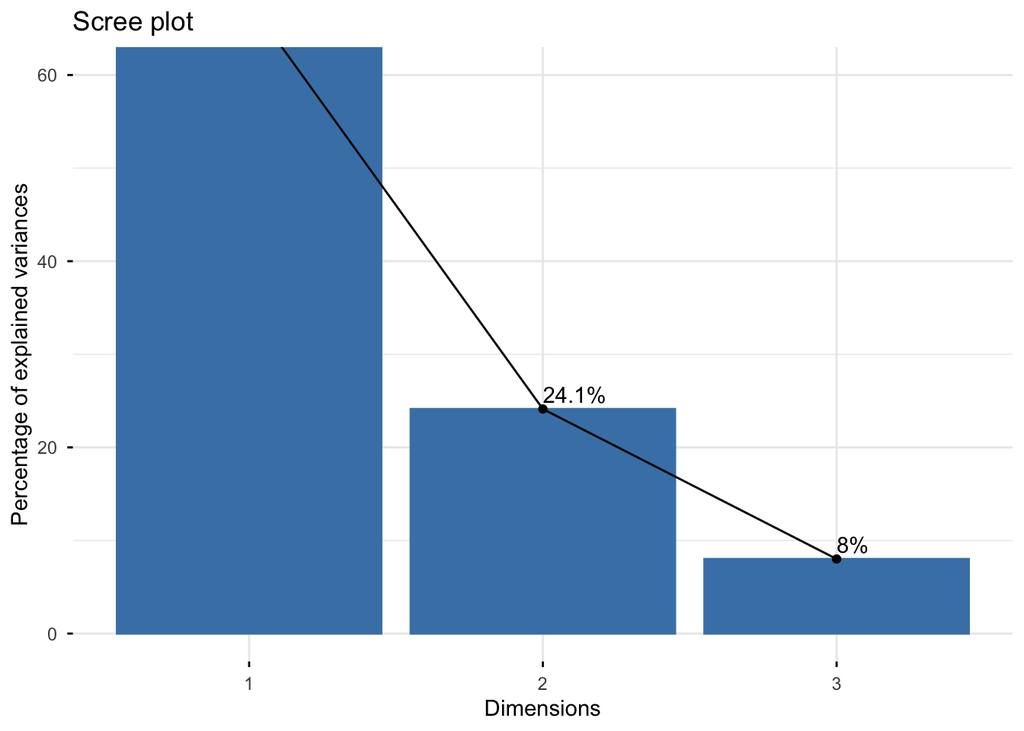

```r
# PCA analysis by cell types####
matrix_pca <- table_log_fc[,c("Macro_num","Lympho_num","Neutro_num")]

rownames(matrix_pca) <- paste0(table_log_fc$Quarter,"_",table_log_fc$Type, "_", table_log_fc$Name)

res.pca <- PCA(log(matrix_pca),
                 graph = F)

eig.val <- get_eigenvalue(res.pca)

fviz_eig(res.pca, addlabels = TRUE, ylim = c(0, 60))
```

```r
ind <- get_pca_ind(res.pca)

color <- as.factor(table_log_fc$Cluster_sample)

tiff(paste0(figure_directory,"/Figure_4_PCA_cytometry_w_cluster_pour_publi.tif"), width = 8.5, height = 8.5, units = "in", res = 150)

fviz_pca_ind(res.pca,
             axes = c(1,2),
             # pointshape = as.factor(table_analyse$Cluster_3_samples),
             pointsize = 5,
             # col.ind = "cos2",
             col.ind=color,
             # fill.ind=color,
             # gradient.cols = c("green","blue","burlywood1","yellow"),
             # palette = c("blue","green","red"),
             palette = c("blue","cyan","burlywood1","red"),
             repel = TRUE, # Avoid text overlapping (slow if many points)
             addEllipses = T,
             ellipse.type = "confidence",
             ellipse.level=0.99,
             mean.point = FALSE,
             label = "none",
             title = paste0(" "),
             legend.title = "Cluster") +
  theme_bw() +
  theme(axis.text.x = element_text(angle=90, size=10),
        axis.text.y = element_text(size=10),
        axis.title.x = element_text(size=15),
        axis.title.y = element_text(size=15),
        axis.title.x.top = element_text(size=25),
        strip.text = element_text(size=15),
        legend.title = element_text(size=20),
        legend.text = element_text(size=15)
  )
```

```
## Ignoring unknown labels:
## • linetype : "Cluster"
```

```r
dev.off()
```

```r
####fin PCA####
```

## Part Three: Annalysis of correlations between sample clusters and metadata

Create figure with the distribution of bacteriological analyses in the different clusters.

```r
#create table with clusters and bacteriology results
table_bacterio <- table_log_fc[,is.element(colnames(table_log_fc),c("Name","Quarter","CCS", "Bacterio"))]
table_bacterio <- merge(table_bacterio, clusters_samples, by = "Quarter")

#generate graph
graph_bacterio <- ggplot(table_bacterio, aes(x = factor(Cluster_sample), fill = factor(Bacterio))) +
  geom_bar(color = "grey", alpha = 1) +
  xlab("Sample clusters") +
  scale_fill_manual(values = c("grey","purple","white", "pink"),
                    name="Bacterio") +
  theme(panel.background = element_rect(fill = "white", colour = "black"),
        axis.text.x = element_text(angle = 0, hjust = 0.5, size=14),
        axis.text.y = element_text(angle = 0, hjust = 0.5, size=14),
        axis.title.y = element_text(angle = 90, hjust = 0.5, size=16),
        axis.title.x = element_text(angle = 0, hjust = 0.5, size=16),
        legend.text = element_text(angle = 0, hjust = 0, size=14),
        legend.title = element_text(angle = 0, hjust = 0, size=16),
        strip.background =element_rect(colour="white", fill="white"),
        panel.grid = element_line(colour="transparent"),
        panel.border = element_rect(colour="black", fill=NA),
        panel.grid.major.x = element_line(colour="transparent"),
        plot.title=element_text(angle = 0, hjust = 0.5, size=12, vjust = 0.5))

tiff(paste0(figure_directory,"/Figure_5_cluster_bacterio.tif"), width = 8.5, height = 8.5, units = "in", res = 150)
graph_bacterio
dev.off()
```

A Likelyhood Ratio Test was performed on bacteriology results to detect if bacteriology results were significantly different among clusters.

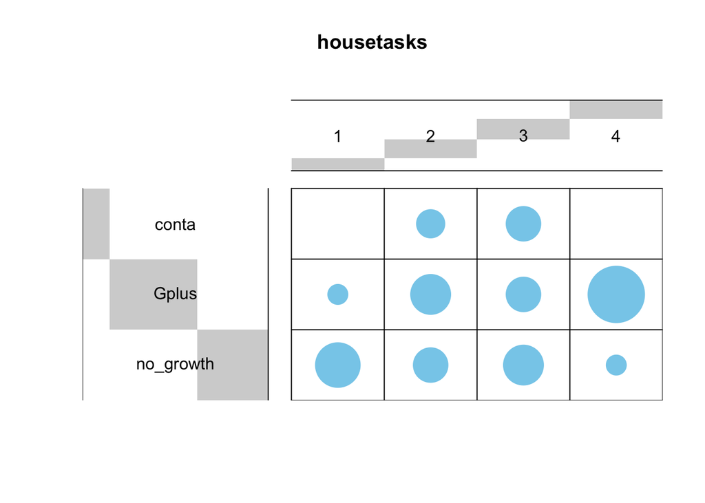

```r
#create a table "dt" sumamrizing bacteriology results among clusters
table_p_value <- table_bacterio[,c(4,5)]
table_p_value <- table_p_value[!is.na(table_p_value$Bacterio),]

dt <- as.table(as.matrix(table(table_p_value)))

balloonplot(t(dt), main ="housetasks", xlab ="", ylab="",
            label = FALSE, show.margins = FALSE)
```

```r
chisq <- chisq.test(as.matrix(table(table_p_value)))
chisq
```

```
##
##  Pearson's Chi-squared test
##
## data:  as.matrix(table(table_p_value))
## X-squared = 14.286, df = 6, p-value = 0.0266
```

```r
GTest(as.matrix(table(table_p_value)))
```

```
##
##  Log likelihood ratio (G-test) test of independence without correction
##
## data:  as.matrix(table(table_p_value))
## G = 15.727, X-squared df = 6, p-value = 0.01529
```

### Histogram of milk sample clusters based on SCC values

SCC values are indicated in the `table_log_fc table`.

```r
# A table is created that contains the name of samples, the quarter ID, the cluster ID and the SCC value
table_histogramme <- table_log_fc[,is.element(colnames(table_log_fc),c("Name","Quarter","CCS"))]
table_histogramme <- merge(table_histogramme, clusters_samples, by = "Quarter")


histogram_CCS_clusters <- ggplot(table_histogramme, aes(x = CCS, fill = factor(Cluster_sample))) +
  geom_histogram(color = "grey", alpha = 1, binwidth = 0.1) +
  scale_x_log10(breaks = c(0,50,100,200,400,1000,4000)) +
  xlab("SCC") +
  scale_fill_manual(values = c("blue","cyan","burlywood1","red"),
                    name = c("Sample clusters")) +
  theme(panel.background = element_rect(fill = "white", colour = "black"),
        axis.text.x = element_text(angle = 0, hjust = 0.5, size=14),
        axis.text.y = element_text(angle = 0, hjust = 0.5, size=14),
        axis.title.y = element_text(angle = 90, hjust = 0.5, size=16),
        axis.title.x = element_text(angle = 0, hjust = 0.5, size=16),
        legend.text = element_text(angle = 0, hjust = 0, size=14),
        legend.title = element_text(angle = 0, hjust = 0, size=16),
        strip.background =element_rect(colour="white", fill="white"),
        panel.grid = element_line(colour="transparent"),
        panel.border = element_rect(colour="black", fill=NA),
        panel.grid.major.x = element_line(colour="transparent"),
        plot.title=element_text(angle = 0, hjust = 0.5, size=12, vjust = 0.5))

tiff(paste0(figure_directory,"/Figure_XX_distribution_SCC_clusters.tif"), width = 8.5, height = 4, units = "in", res = 150)
print(histogram_CCS_clusters)
dev.off()
```

### Distribution related to days-in-milk

```r
#create table with clusters and bacteriology results
table_DIM <- table_log_fc[,is.element(colnames(table_log_fc),c("Name","Quarter","CCS", "Days_in_milk"))]
table_DIM <- merge(table_DIM, clusters_samples, by = "Quarter")

#generate graph
graph_DIM <- ggplot(table_DIM, aes(x = Days_in_milk, fill = factor(Cluster_sample))) +
  geom_histogram(color = "grey", alpha = 1) +
  xlab("DIM") +
  scale_fill_manual(values = c("blue","cyan","burlywood1","red"),
                    name = c("Sample clusters")) +
  theme(panel.background = element_rect(fill = "white", colour = "black"),
        axis.text.x = element_text(angle = 0, hjust = 0.5, size=14),
        axis.text.y = element_text(angle = 0, hjust = 0.5, size=14),
        axis.title.y = element_text(angle = 90, hjust = 0.5, size=16),
        axis.title.x = element_text(angle = 0, hjust = 0.5, size=16),
        legend.text = element_text(angle = 0, hjust = 0, size=14),
        legend.title = element_text(angle = 0, hjust = 0, size=16),
        strip.background =element_rect(colour="white", fill="white"),
        panel.grid = element_line(colour="transparent"),
        panel.border = element_rect(colour="black", fill=NA),
        panel.grid.major.x = element_line(colour="transparent"),
        plot.title=element_text(angle = 0, hjust = 0.5, size=12, vjust = 0.5))

tiff(paste0(figure_directory,"/Supplementary_Figure_S3_distribution_DIM_cluster.tif"), width = 8.5, height = 4, units = "in", res = 150)
graph_DIM
dev.off()
```

### Distribution SCC related to breed

```r
#create table
table_SCC_breed <- table_log_fc[,is.element(colnames(table_log_fc),c("Name","Quarter","CCS", "Breed"))]

#generate graph
graph_breed <- ggplot(table_SCC_breed, aes(x = CCS, fill = factor(Breed))) +
  geom_histogram(color = "black", alpha = 1, binwidth = 0.1) +
  scale_x_log10() +
  xlab("SCC") +
  scale_fill_manual(values = c("grey","purple","white"),
                    name="Breed") +
  theme(panel.background = element_rect(fill = "white", colour = "black"),
        axis.text.x = element_text(angle = 0, hjust = 0.5, size=14),
        axis.text.y = element_text(angle = 0, hjust = 0.5, size=14),
        axis.title.y = element_text(angle = 90, hjust = 0.5, size=16),
        axis.title.x = element_text(angle = 0, hjust = 0.5, size=16),
        legend.text = element_text(angle = 0, hjust = 0, size=14),
        legend.title = element_text(angle = 0, hjust = 0, size=16),
        strip.background =element_rect(colour="white", fill="white"),
        panel.grid = element_line(colour="transparent"),
        panel.border = element_rect(colour="black", fill=NA),
        panel.grid.major.x = element_line(colour="transparent"),
        plot.title=element_text(angle = 0, hjust = 0.5, size=12, vjust = 0.5))

tiff(paste0(figure_directory,"/Supplementary_figure_S2_distribution_SCC_breed.tif"), width = 8.5, height = 4, units = "in", res = 150)
graph_breed
dev.off()
```

### Comparison of clustering obtained by flow cytometry and gene expression profile

Then dendrogram from the analysis of gene expression data and flow cytometry data on milk composition are analyzed.

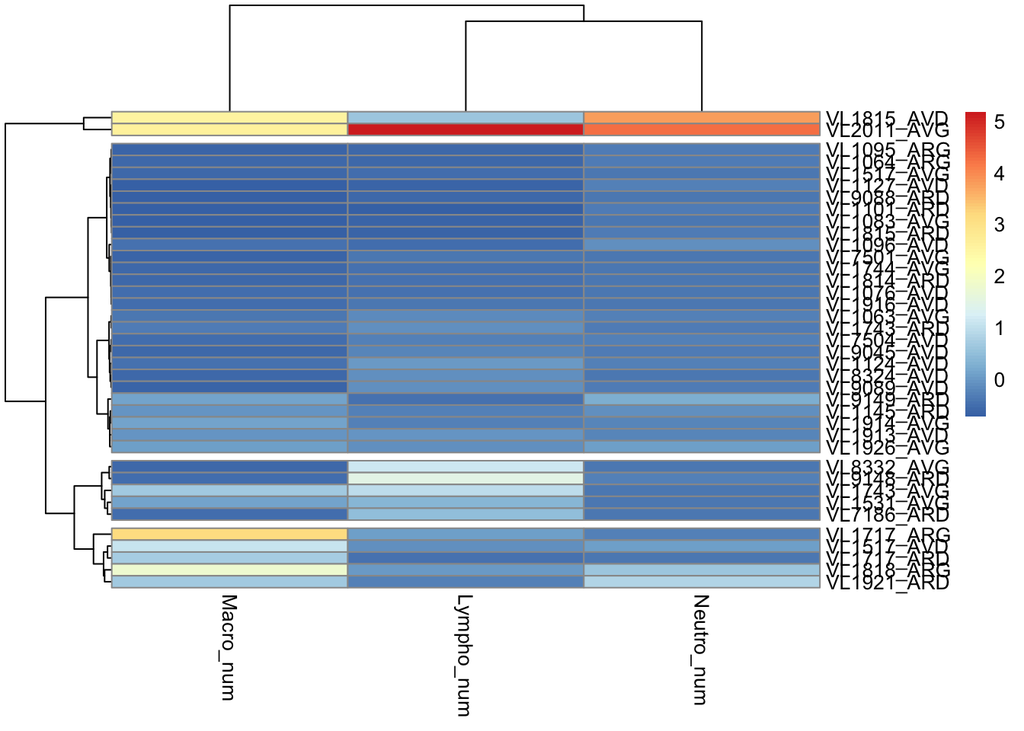

```r
dendro_expression <- p_milk_samples[[1]] %>%
    as.dendrogram()

#dendogramme cytometrie
matrix_pca_cytometrie <- as.matrix(table_log_fc[,c("Macro_num","Lympho_num", "Neutro_num")])
rownames(matrix_pca_cytometrie) <- table_log_fc$Quarter
matrix_pca_cytometrie <- scale(matrix_pca_cytometrie)

p_cytometrie <- pheatmap(matrix_pca_cytometrie,
                           cutree_rows = 4,
                           clustering_method="ward.D",
                           clustering_distance_cols ="euclidean",
                           clustering_distance_rows ="euclidean")
```

```r
dendro_cytometrie <- p_cytometrie[[1]] %>%
    as.dendrogram()

# Compute distance matrix####

#voir http://talgalili.github.io/dendextend/articles/dendextend.html
# Create a list to hold dendrograms
dend_list <- dendlist(dendro_expression, dendro_cytometrie)

# Align and plot two dendrograms side by side
set.seed(1)

tiff(paste0(figure_directory,"/Figure_XX_tanglegram.tif"), width = 8.5, height = 8.5, units = "in", res = 150)
dendlist(dendro_expression, dendro_cytometrie) %>%
  untangle(method = "step2side") %>% # Find the best alignment layout
  tanglegram(main_left = "dendrogramme expression",
             main_right = "dendrogramme cytometrie",
             columns_width = c(5,3,5),
             margin_inner = 8,
             cex_main = 1.5)



dev.off()
```

```r
cor_bakers_gamma(dendro_expression, dendro_cytometrie)
```

```
## [1] 0.235933
```

```r
#Baker’s Gamma Index
#
# Baker’s Gamma Index (see baker’s paper from 1974) is a measure of association (similarity) between two trees of Hierarchical clustering (dendrograms).
# It is defined as the rank correlation between the stages at which pairs of objects combine in each of the two trees.
#
# Or more detailed: It is calculated by taking two items, and see what is the highest possible level of k (number of cluster groups created when cutting the tree) for which the two item still belongs to the same tree.
# That k is returned, and the same is done for these two items for the second tree.
# There are n over 2 combinations of such pairs of items from the items in the tree, and all of these numbers are calculated for each of the two trees.
# Then, these two sets of numbers (a set for the items in each tree) are paired according to the pairs of items compared, and a Spearman correlation is calculated.
#
# The value can range between -1 to 1. With near 0 values meaning that the two trees are not statistically similar.
# For exact p-value one should use a permutation test. One such option will be to permute over the labels of one tree many times, calculating the distribution under the null hypothesis (keeping the trees topologies constant).
#
# Notice that this measure is not affected by the height of a branch but only of its relative position compared with other branches.


set.seed(23235)
the_cor <- cor_bakers_gamma(dendro_expression, dendro_expression)
the_cor2 <- cor_bakers_gamma(dendro_expression, dendro_cytometrie)
the_cor
```

```
## [1] 1
```

```r
the_cor2
```

```
## [1] 0.235933
```

```r
R <- 1000
cor_bakers_gamma_results <- numeric(R)
dend_mixed <- dendro_expression
for(i in 1:R) {
  dend_mixed <- sample.dendrogram(dend_mixed, replace = FALSE)
  cor_bakers_gamma_results[i] <- cor_bakers_gamma(dendro_expression, dend_mixed)
}

tiff(paste0(figure_directory,"/Supplementary_figure_S4_Baker_index.tif"), width = 8.5, height = 8.5, units = "in", res = 150)
plot(density(cor_bakers_gamma_results),
     main = "Baker's gamma distribution under H0",
     xlim = c(-1,1))
abline(v = 0, lty = 2)
# abline(v = the_cor, lty = 2, col = 2)
abline(v = the_cor2, lty = 2, col = 4)
legend("topleft", legend = c("Baker's index"), fill = c(4))
round(sum(the_cor2 < cor_bakers_gamma_results)/ R, 4)
```

```
## [1] 0.002
```

```r
title(sub = paste("One sided p-value:", round(sum(the_cor2 < cor_bakers_gamma_results)/ R, 4))
)

dev.off()
```